# NTW prelim data analysis

# information & todo

here is code for some analysis of preliminary NTW experiments. as usual i keep making 50 different new files for things bc im indecisive about how to do things

TODO list: (search `// TODO`)

- [done] create `daysto.` columns (from hatching) for all instars/development timepoints
- consolidate todo items up here lol (then redistribute to below… or vice versa)

TODO / statistics to measure:

- [!!!] lowkey double check that #s are right due to what we discovered with the na_drop!!!
- [done] log average weight at instars
  - h/m considerations… (esp for grp B)
  - from.E considerations… (only pick 0 and 1?)
  - for clarity, should come up w better naming system for the adults/larva + groupings
- [done for A, B] average length of instars
- [doneish] survival
  - kaplan meier curves – see:
    - https://rviews.rstudio.com/2017/09/25/survival-analysis-with-r/
    - https://www.emilyzabor.com/tutorials/survival_analysis_in_r_tutorial.html#Packages
- [done] A vs B comparisons (26 constant)
  - [done] pool relevant A+B individuals –> then stats again?
- who got stuck
- pupa development (looking @ % none? idr what i originally meant here)
- dv coloring (with B only)
- graph a bunch of growth lines + avg growth
- [in prog] plot time vs mass (dot plot w/ error bars on both sides)

experiment groups:

- A: 2x2 of mean temp = 26 or 33, with 0 degC fluct or 7 degC fluct
- B:
  - redoing 337 from hatching (A)
  - 2x2(ish) of entering 260 or 337 treatment at different times (hatch, 3rd, 4th)

# load packages (use the setup chunk instead)

```r
# library(dplyr)
# library(ggplot2)
# library(tidyr)

# for some reason this broke on 230321 so now use the setup chunk

#library(data.table) #for setDT (forget why i was thinking about this one)
#library(survival) # for kaplan-meier
```

# load in data and clean, labels

outputs

- data_all, data_notes, data (surv to pup)
  - maybe rename data to data_ec (surv to eclosion)
- data_A, data_B

```r
#load(file="dfs.RData")
```

```r
data_all <- read.csv("~/Documents/repos/_not-public/1_data/ntw_data/development_v2.csv", header = T) # change to this bc v1 is missing some info
data_all <- mutate_all(data_all, na_if, "") # remove na lines introduced during import
data_all <- data_all[rowSums(is.na(data_all)) != ncol(data_all),]

# filter out things that didnt hatch at 26C
data_all <- data_all %>%
    filter(!(from.E == 2 | (from.E == 0 & (treatment == 337 | treatment == 330 | treatment == 267))))

# save wordier notes elsewhere and remove from analysis dataset
data_notes <- select(data_all, c("from.E", "treatment", "ID", "expt.group", "pupa.deformities", "final.fate", "notes"))
data_pup <- select(data_all, -c("notes", "pupa.deformities", "mass.died", "time.in.approx"))
  # not sure if 'notes' column will mess things up

# create julian date columns, additional column fixing
data_all <- data_all %>% mutate(across(starts_with("date."),  as.Date, format = "%m/%d/%y")) %>%
  mutate(across(starts_with("date."), format, "%j", .names = "j{.col}")) %>%
  mutate(across(starts_with("jdate."), as.numeric),
         across(starts_with("mass."), as.numeric),
         treatment = as.character(treatment),
         trt.stage = as.character(paste(treatment,instar.enter, sep = "-")), # treatment @ instar
         grp.trt = paste(expt.group, trt.stage, sep = "-"), # round @ treatment
         meanT = ifelse((treatment=="260" | treatment=="267"), 26, 33),
         fluct = ifelse((treatment == "260" | treatment == "330"), 0, 7))

#data_all$trt.stage <- factor(data_all$trt.stage, levels = c("260-hatch", "267-hatch", "330-hatch", "337-hatch", "337-3rd", "337-4th"))

# keep individuals that survived to pupation
#data_pup <- data_all %>% filter(reason.pmd == "" | reason.pmd == "pupa" | reason.pmd == "toast" )
data_pup <- data_all %>% filter(final.fate == "accidental" | final.fate == "eclose" | final.fate == "pupa")
  # omit the LPs? -> currently yes

# pivot and make subsets
long <- data_pup %>% select(-(starts_with("date."))) %>%
                 pivot_longer(cols = starts_with(c("jdate", "mass", "h")),
                        names_to = c(".value", "instar"),
                        #names_sep = ".",
                        values_drop_na = TRUE,
                        names_pattern = ("([a-z]*)\\.(\\d*[a-z]*)")) %>%
                 rename(molt.status = h) %>%
                 drop_na(jdate) # drops NA's if an individual didnt reach a certain stage

long <- long[long$instar != "in",] # from 'instar.in.trt'?
long$instar <- factor(long$instar, c("hatch", "2nd", "3rd", "4th", "5th", "stuck", "wander", "15", "pupa", "eclose"))

# create subsets
data_A <- long[long$expt.group == "A",]
data_B <- long[long$expt.group == "B",]

# defining factors, labels
# A: effect of temp (treatment)
A_trts = c("260-hatch", "267-hatch", "330-hatch", "337-hatch")
# A_hex = c("#abd9e9","#2c7bb6", "#fdae61", "#d7191c")
# A_colors <- c("260-hatch"="#abd9e9","267-hatch"="#2c7bb6", "330-hatch"="#fdae61", "337-hatch"="#d7191c")
A_labels <- c("260-hatch"="26°C", "267-hatch"="26±7°C", "330-hatch"="33°C", "337-hatch"="33±7°C")
A_hex = c("#00C2D1","#1929B3", "#F9C639", "#710A36")
A_colors <- c("260-hatch"="#00C2D1","267-hatch"="#1929B3", "330-hatch"="#F9C639", "337-hatch"="#710A36")



# B: effect of temp:instar (trt.stage)
B_trts = c("260-hatch", "337-hatch", "337-3rd", "337-4th") # manually set factor levels
# B_hex = c("#abd9e9", "#fdbe85", "#fd8d3c", "#d94701")
# B_colors = c("260-hatch"="#abd9e9", "337-4th"="#fdbe85", "337-3rd"="#fd8d3c", "337-hatch"="#d94701")
B_labels = c("260-hatch"="26°C @ hatch","337-hatch"="33±7°C @ hatch", "337-3rd"="33±7°C @ 3rd", "337-4th"="33±7°C @ 4th")
B_hex = c("#00C2D1", "#710A36", "#C23C1E", "#F3922B")
B_colors = c("260-hatch"="#00C2D1", "337-hatch"="#710A36", "337-3rd"="#C23C1E", "337-4th"="#F3922B")
#CD133F

all_trts <- c("260-hatch", "267-hatch", "330-hatch", "337-hatch", "337-3rd", "337-4th")

# save all this as .RData file (delete later)
#save(data_all, data_notes, data, long, data_A, data_B, A_colors, A_labels, B_trts, B_colors, B_labels, file="dfs.RData")
```

# AB pooled

## AB2 pooled mass&dev analysis

[done!!!!!] want to look at mass/dev time simultaneously on y/x axes respectively

- need to calc: log.se.mass, se.days.to
  - can use the lstats_AB and astats_AB

```r
# larva/adult mass @ instars
  # pupa/adults need to be separated from the larva before summarising bc of sex differences

# take out things that didn't hatch @ 26C
# AB2_lmass <- long %>%
#   filter(!(from.E == 0 & (treatment == 337 | treatment == 330 | treatment == 267)))

# these 2 should work bc i fixed "long"
AB2_lmass <- long %>%
  filter(instar == "3rd" | instar == "4th" | instar == "5th" | instar == "wander") %>%
  group_by(instar, trt.stage) %>%
  mutate(logmass = log(mass)) %>%
  summarise(avg.mass = mean(mass),
            se.mass = sd(mass)/sqrt(length(mass)),
            avg.logmass = mean(logmass),
            se.logmass = sd(logmass)/sqrt(length(logmass)),
            n=n())
AB2_amass <- long %>%
  group_by(trt.stage, sex, instar) %>%
  filter(instar == "pupa" | instar == "eclose") %>%
  summarise(avg.mass = mean(mass),
            se.mass = sd(mass)/sqrt(length(mass)),
            n=n())
# calculate development time (instar duration), then split into larva/adults + summarise
AB2_devtime <- data_pup %>%
  select(-starts_with(c("h", "date", "mass", "reason."))) %>%
  mutate("2nd" = jdate.2nd - jdate.hatch,
         "3rd" = jdate.3rd - jdate.hatch,
         "4th" = jdate.4th - jdate.hatch,
         "5th" = jdate.5th - jdate.hatch,
         wander = jdate.wander - jdate.hatch,
         pupa = jdate.pupa - jdate.wander,
         #eclose = jdate.eclose - jdate.15
         eclose = jdate.eclose - jdate.pupa) %>%
  select(-starts_with("jdate.")) %>%
  pivot_longer (cols = c("2nd", "3rd", "4th", "5th", "wander", "pupa", "eclose"), # pivot differences by stage
                names_to = "instar",
                values_to = "days.to") %>%
  na.omit(days.to)

AB2_ldev <- AB2_devtime %>%
  filter(instar == "3rd" | instar == "4th" | instar == "5th" | instar == "wander") %>%
  group_by(trt.stage, instar) %>%
  summarise(avg.daysto = mean(days.to),
            se.daysto = sd(days.to)/sqrt(length(days.to)))
AB2_adev <- AB2_devtime %>%
  filter(instar == "pupa" | instar == "eclose") %>%
  group_by(trt.stage, sex, instar) %>%
  summarise(avg.daysto = mean(days.to),
            se.daysto = sd(days.to)/sqrt(length(days.to)))
# merge into larval/adult stats
#lstats_AB2 <- merge(lmass_AB2, ldev_AB2, cols = c("trt.stage", "instar"))
AB2_lstats <- merge(AB2_lmass, AB2_ldev, all = T)
AB2_astats <- merge(AB2_amass, AB2_adev, all = T)


# create subsets for plotting effect of temp and temp @ instar
# temp effect subsets
AB2_ltemps <- AB2_lstats %>% filter(trt.stage != "337-3rd" & trt.stage != "337-4th")
AB2_atemps <- AB2_astats %>% filter(trt.stage != "337-3rd" & trt.stage != "337-4th")

# temp+instar effects subsets
AB2_linstar <- AB2_lstats %>% filter(trt.stage != "267-hatch" & trt.stage != "330-hatch")
AB2_linstar$trt.stage <- factor(AB2_linstar$trt.stage, levels = c("260-hatch", "337-hatch", "337-3rd", "337-4th"))
AB2_ainstar <- AB2_astats %>% filter(trt.stage != "267-hatch" & trt.stage != "330-hatch")
AB2_ainstar$trt.stage <- factor(AB2_ainstar$trt.stage, levels = c("260-hatch", "337-hatch", "337-3rd", "337-4th"))

# AB2_linstar2 <- AB2_lstats %>% filter(trt.stage != "267-hatch")
# AB2_ainstar2 <- AB2_astats %>% filter(trt.stage != "267-hatch")
```

## AB2 pooled mass&dev plots

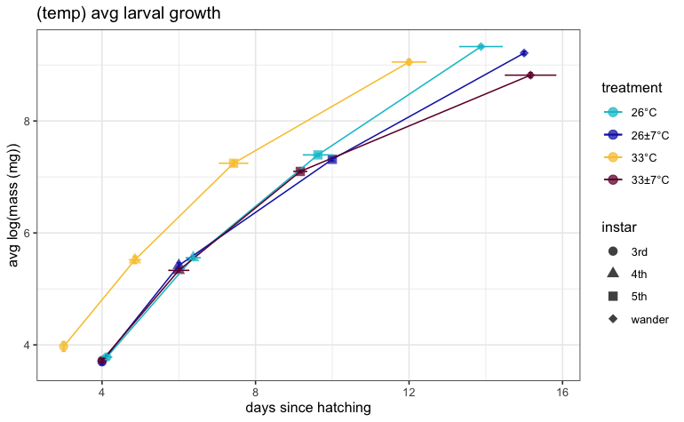

```r
# I REALLY HOPE THESE ARE DONE....


### plots comparing effect of temps ###
# larval mass/dev
AB2_ltemps %>%
  ggplot(aes(x = avg.daysto, y = avg.logmass, shape=instar, color=trt.stage)) +
  geom_point(size=3, alpha=0.75) +
  scale_shape_manual(values=c(16, 17, 15, 18))+
  geom_line(aes(group = trt.stage)) +
  geom_errorbarh(aes(xmin= avg.daysto - se.daysto, xmax = avg.daysto + se.daysto)) +
  geom_errorbar(aes(ymin = avg.logmass - se.logmass, ymax = avg.logmass + se.logmass)) +
  labs(title = "(temp) avg larval growth", x = "days since hatching", y = "avg log(mass (mg))", color = "treatment") +
  scale_color_manual(labels=A_labels, values = A_colors) + theme_bw()
```

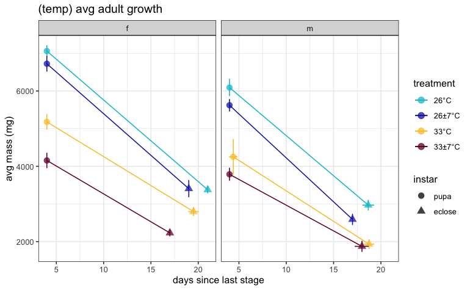

```r
# adult mass/dev
AB2_atemps %>%
  ggplot(aes(x = avg.daysto, y = avg.mass, color=trt.stage, shape=instar)) +
  geom_point(size=3, alpha = 0.75) +
  geom_line(aes(group = trt.stage)) +
  geom_errorbarh(aes(xmin= avg.daysto - se.daysto, xmax = avg.daysto + se.daysto)) +
  geom_errorbar(aes(ymin = avg.mass - se.mass, ymax = avg.mass + se.mass)) +
  facet_wrap(~sex) +
  labs(title = "(temp) avg adult growth", y = "avg mass (mg)", x = "days since last stage", color = "treatment") +
  scale_color_manual(values = A_colors, labels=A_labels) + theme_bw()
```

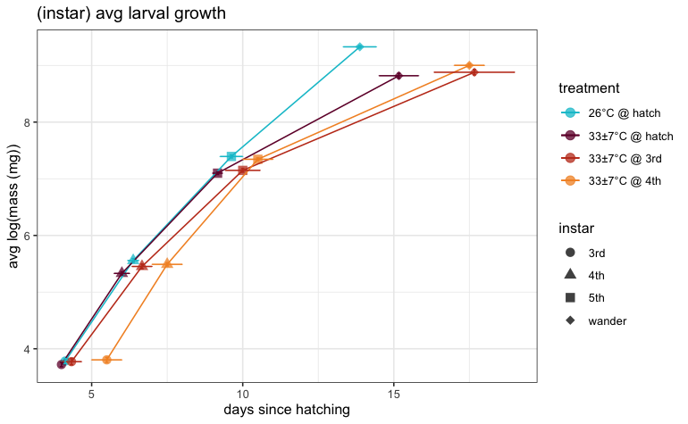

```r
### plots comparing effect of temp x instar ###
# larval mass/dev
  # hard to see shapes...
AB2_linstar %>%
  ggplot(aes(x = avg.daysto, y = avg.logmass, shape=instar, color=trt.stage)) +
  geom_point(size=3, alpha = 0.75) +
  scale_shape_manual(values=c(16, 17, 15, 18))+
  geom_line(aes(group = trt.stage)) +
  geom_errorbarh(aes(xmin= avg.daysto - se.daysto, xmax = avg.daysto + se.daysto)) +
  geom_errorbar(aes(ymin = avg.logmass - se.logmass, ymax = avg.logmass + se.logmass)) +
  labs(title = "(instar) avg larval growth", x = "days since hatching", y = "avg log(mass (mg))", color = "treatment") +
  scale_color_manual(labels = B_labels, values = B_colors) + theme_bw()
```

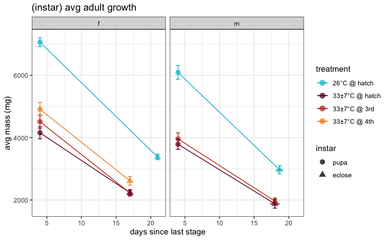

```r
    ## looks kinda wrong w rerun analyses? (lines dont seem like they grouped right..)

# adult mass/dev
AB2_ainstar %>%
  ggplot(aes(x = avg.daysto, y = avg.mass, shape=instar, color=trt.stage)) +
  geom_point(size=3, alpha = 0.75) +
  geom_line(aes(group = trt.stage)) +
  facet_wrap(~sex) +
  geom_errorbarh(aes(xmin= avg.daysto - se.daysto, xmax = avg.daysto + se.daysto)) +
  geom_errorbar(aes(ymin = avg.mass - se.mass, ymax = avg.mass + se.mass)) +
  scale_color_manual(labels = B_labels, values = B_colors) + theme_bw() +
  labs(title = "(instar) avg adult growth", y = "avg mass (mg)", x = "days since last stage", color="treatment")
```

# overall survivorship/kill curves

- who died? (pmd) pre or post 3rd? did all slow growers die?
  - want to add columns for this!
  - how to grp trts? (by mean/fluct/instar? or mean-fluct/instar?)
- visualise: curve + do stacked bars (for an overview)?

## kaplan-meier curves

- b/g reading
  - general ideas https://datatab.net/tutorial/survival-analysis
    - prob use cox to account for instar entered, trt, stuck in 5th
      - http://www.sthda.com/english/wiki/cox-proportional-hazards-model
      - https://rstudio-pubs-static.s3.amazonaws.com/5896_8f0fed2ccbbd42489276e554a05af87e.html
- probably use [this](https://dk81.github.io/dkmathstats_site/rvisual-kaplan-meier.html)
  - https://argoshare.is.ed.ac.uk/healthyr_book/recode-the-data-1.html
    - look into [cox.zph](https://argoshare.is.ed.ac.uk/healthyr_book/cox-proportional-hazards-regression.html) for stuck?

variables needed

- id, trt, etc (group curves by trt?)
- time to pmd/event (death as LP, P, L)
- censorship for other events (stuck)

### attempt 2

```r
# redo of orig KM analysis
  # censor out eclosed + toasted individuals
  # redo fate codes
  # subset later into temp/temp+instar trts...?
  # change analysis times - to pupation? to wandering? (start at hatch? in trt?)
    # so need to determine when the general exit day was

## hard code fate data in R

# levels(as.factor(data_all$reason.pmd))
  # double check what the possible outcomes are
  # ""         "empty"    "LP"       "pmd"      "pupa"     "squished" "toast"

## reference: making new columns for survival analyses. censoring is different based on what the endpoint is
# dfs: surv_ec, surv_pup, surv_wander
# columns: dins (instar died), dstage (life stage died), censor = for KM, date.exit = depends on endpt

# hardcoding final outcomes + addtl info (overall)
  # hardcode up to 4th instar survival -- rest is based on endpt
surv2 <- data_all %>%
  filter(final.fate != "misc") %>% # remove accidental deaths from overall analysis
  mutate(dins = case_when(is.na(date.2nd) ~ 1, # died as 1st instar
                          is.na(date.3rd) ~ 2,
                          is.na(date.4th) ~ 3,
                          reason.pmd != "toast" & is.na(date.5th) ~ 4,
                          reason.pmd == "toast" ~ 99)) # the toasted ones

# test:  test2 <- filter(surv_ec, dstage == 5)

# subset: endpoint = eclosion
surv_ec <- surv2 %>%
  mutate(dins = case_when(reason.pmd != "toast" & is.na(date.pupa) & is.na(date.LP) ~ 5, # died as 5th instar
                          !is.na(date.LP) ~ 6, # died as LPI
                          !is.na(date.pupa) & is.na(date.eclose) ~ 7, # died as pupa
                          reason.pmd == "toast" ~ 99, # toasted
                          TRUE ~ 0), # eclosed
         censor = ifelse((dins == 0 | dins == 99), 0, 1), # 0 = to eclosion, 1 = died
         dstage = case_when(dins == 1 | dins == 2 | dins == 3 | dins == 4 | dins == 5 ~ 1,
                            dins == 6 ~ 2, # LP
                            dins == 7 ~ 3, # P
                            dins == 0 | dins == 99 ~ 0), # censor eclosion or toast
         date.exit = case_when(dstage == 1 ~ date.pmd, # exit time if to eclosion
                               dstage == 2 ~ date.LP,
                               dstage == 3 ~ as.Date(jdate.15+10, format = "%m/%d/%y", origin = date.hatch),
                               dins == 99 ~ date.pmd,
                               dins == 0 ~ date.eclose),
         subset = "to.ec")


# subset: endpoint = pupation
surv_pup <- surv2 %>%
  mutate(dins = case_when(reason.pmd != "toast" & is.na(date.pupa) & is.na(date.LP) ~ 5, # died as 5th instar
                          !is.na(date.LP) ~ 6, # died as LPI
                          reason.pmd == "toast" ~ 99, # toasted
                          TRUE ~ 0), # pupated
         censor = ifelse((dins == 0 | dins == 99), 0, 1), # 0 = to pupation, 1 = died
         dstage = case_when(dins == 1 | dins == 2 | dins == 3 | dins == 4 | dins == 5 ~ 1, # died larva
                            dins == 6 ~ 2, # died LP
                            dins == 0 | dins == 99 ~ 0), # censor pupation or toast
         date.exit = case_when(dstage == 1 ~ date.pmd, # exit time if to pupation
                               dstage == 2 ~ date.LP,
                               !is.na(date.pupa) & is.na(date.eclose) ~ as.Date(jdate.15+10, format = "%m/%d/%y", origin = date.hatch),
                               dins == 99 ~ date.pmd,
                               dins == 0 ~ date.pupa),
         subset = "to.pup")

# subset: endpoint = wandering
surv_wand <- surv2 %>%
  mutate(dins = case_when(reason.pmd != "toast" & is.na(date.wander) ~ 5, # died pre-wandering,
                          reason.pmd == "toast" ~ 99, # toasted
                          TRUE ~ 0), # wandered
         censor = ifelse((dins == 0 | dins == 99), 0, 1), # 0 = to wandering, 1 = died
         dstage = case_when(dins == 1 | dins == 2 | dins == 3 | dins == 4 | dins == 5 ~ 1, # died larva
                            dins == 0 | dins == 99 ~ 0), # censor wandering or toast
         date.exit = case_when(dstage == 1 ~ date.pmd, # exit time if to wandering
                               dins == 99 ~ date.pmd,
                               dins == 0 ~ date.wander),
         subset = "to.wand")
          # could try coalesce() here next time


# merge into 1 df for convenience
surv3 <- do.call("rbind", list(surv_ec, surv_pup, surv_wand))
#surv3$subset <- levels(c()) (maybe change levels)

# calculate exit times
surv3 <- surv3 %>%
  mutate(timeto.exit.hatch = as.numeric(format.Date(date.exit, format = "%j")) - jdate.hatch,
         timeto.exit.intrt = as.numeric(format.Date(date.exit, format = "%j")) - jdate.in.trt)
```

```r
## sanity check - look at events
table(surv_ec$dins, surv_ec$censor)
  #      0   1
  # 0  157   0
  # 5    0  13
  # 6    0   2
  # 7    0   4
  # 99  24   0

table(surv_ec$dstage, surv_ec$censor)
  #     0   1
  # 0 181   0
  # 1   0  13
  # 2   0   2
  # 3   0   4


table(surv_pup$dins, surv_pup$censor)
  #      0   1
  # 0  161   0
  # 5    0  13
  # 6    0   2
  # 99  24   0

table(surv_pup$dstage, surv_pup$censor)
  #     0   1
  # 0 185   0
  # 1   0  13
  # 2   0   2


table(surv_wand$dins, surv_wand$censor)
  #      0   1
  # 0  165   0
  # 5    0  11
  # 99  24   0

table(surv_wand$dstage, surv_wand$censor)
  #     0   1
  # 0 189   0
  # 1   0  11
```